# strong continuous bivariate marker with discrete risk distribution

marshall

Thursday, May 08, 2014

### Simulation attributes

We simulate two different discrete risk distributions using a continuous bivariate normal marker. The simulations on this page pertain to the ‘discrete’ case.

- **discrete:** *marker measurement remains continuous, but risk for each individual is contrained to be one of four discrete values. This is achieved through use of a bivariate marker, where $x_1$ is standard normal and $x_2$ is a function of $x_1$. Mathematically:* $\begin{aligned} r^* & \in \{r_1, r_2, r_3, ...\} \\ x_1 & \sim N(0, 1) \\ x_2 & = (logit(r^*) - \beta_0 - \beta_1 x )/ \beta_2 \\ \end{aligned}$
- **discrete + noise:** *identical to the discrete case, but instead of $x_2$ being determined by $x_1$ such that risk is one of four discrete values, $x_2$ is generated from a normal distribution centered at the value such that risk is discrete. Mathematically:* $\begin{aligned} r^* & \in \{r_1, r_2, r_3, ...\} \\ x_1 & \sim N(0, 1) \\ x_2 & \sim N((logit(r^*) - \beta_0 - \beta_1 x )/ \beta_2, sd = risk.tune) \\ \end{aligned}$

The following parameters where used to model risk.

- **risk bins:** 0.05, 0.19, 0.3, 0.5 The values risk could take on.
- **risk bin weights:** 0.5, 0.32, 0.13, 0.05 The proportion of the population fall into each risk bin.
- **riskbin tune (sd):** 0 The level of noise added to the risk bins. Zero here means no noise was added.

#### other attributes

- **marker strength:** strong
- **marker measurement:** continuous
- **marker dimension:** bivariate
- **risk distribution constraints:** discrete
- **control proportion near boundary:** no

### Marker values

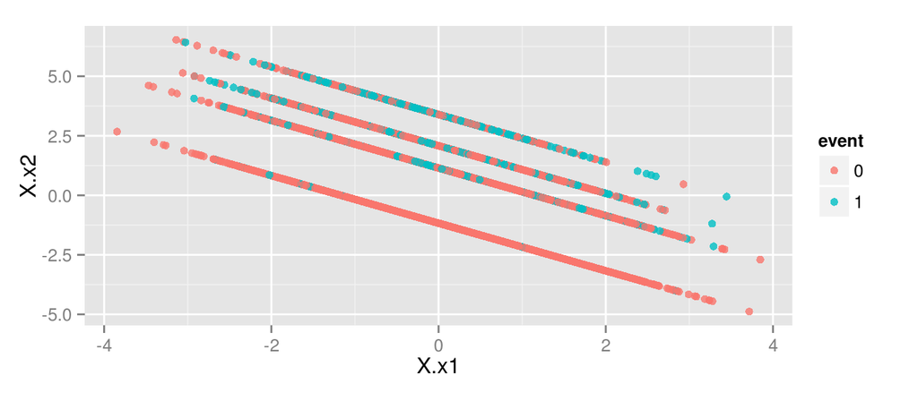

### Risk distributions

High risk threshold shown as black vertical line.

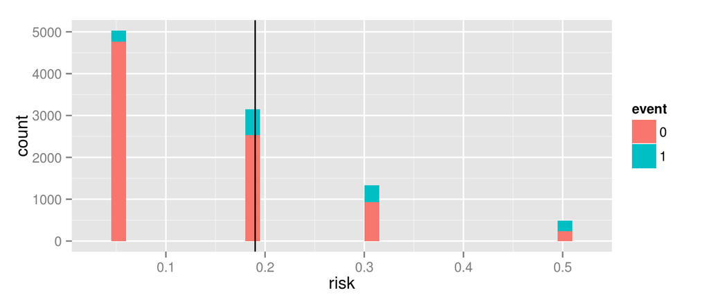

### Sampling distributions for accuracy measure estimates

From 5000 simulated datasets. Mean values shown as vertical lines. True measure value shown as black dashed line.

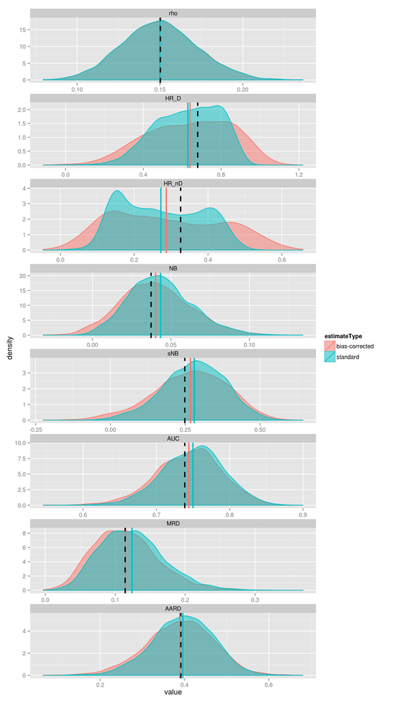

### Coverage of 95% CI’s

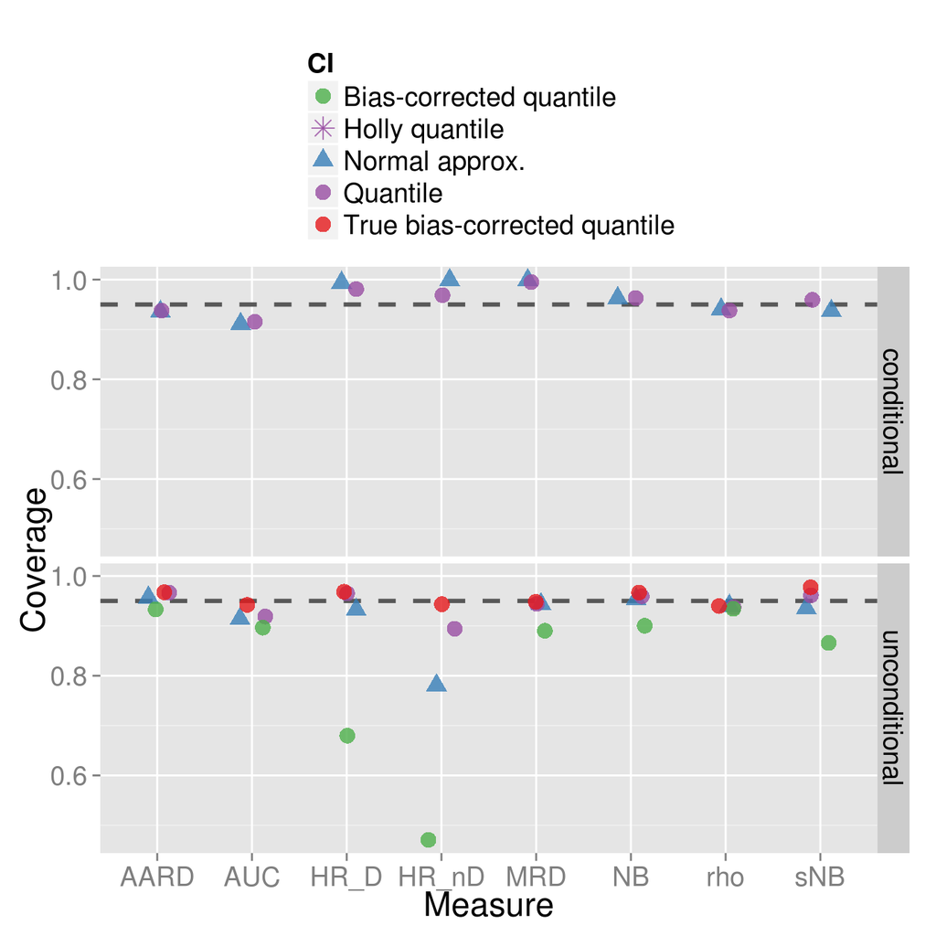

### Bias

Table of median % bias.

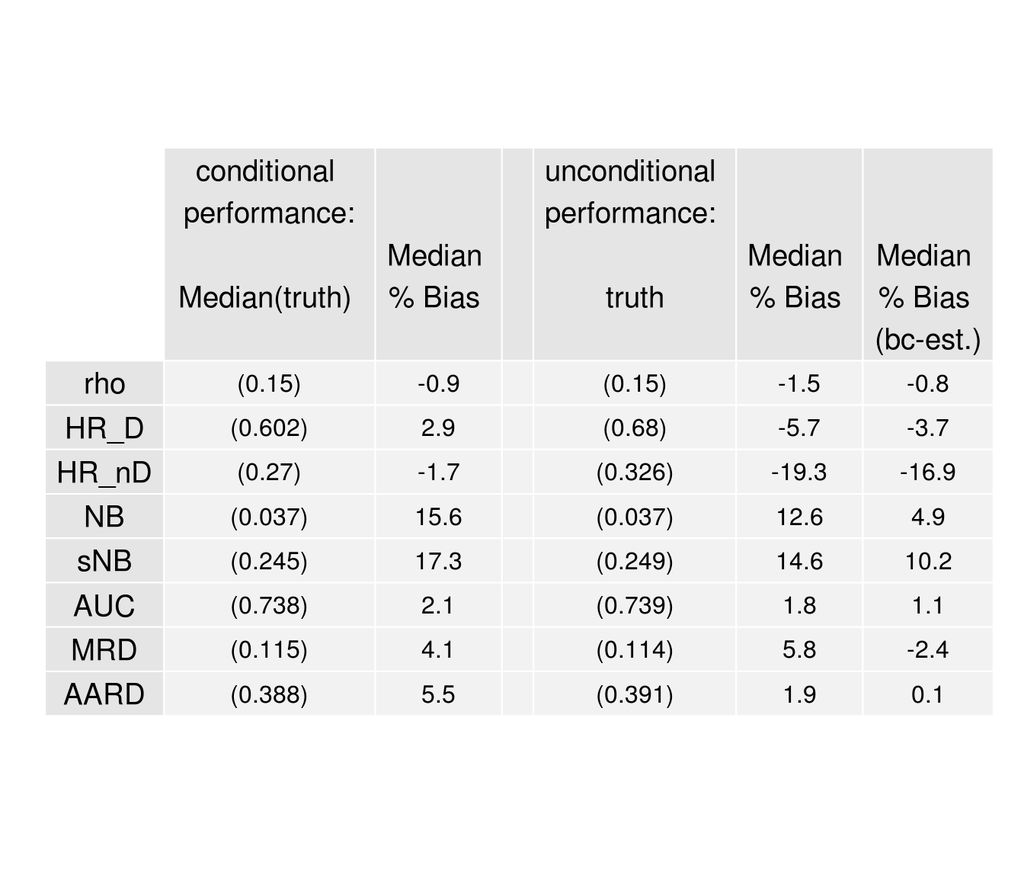

Plot of absolute bias for conditional/unconditional performance. For unconditional performance we show both standard and bias-corrected estimates.

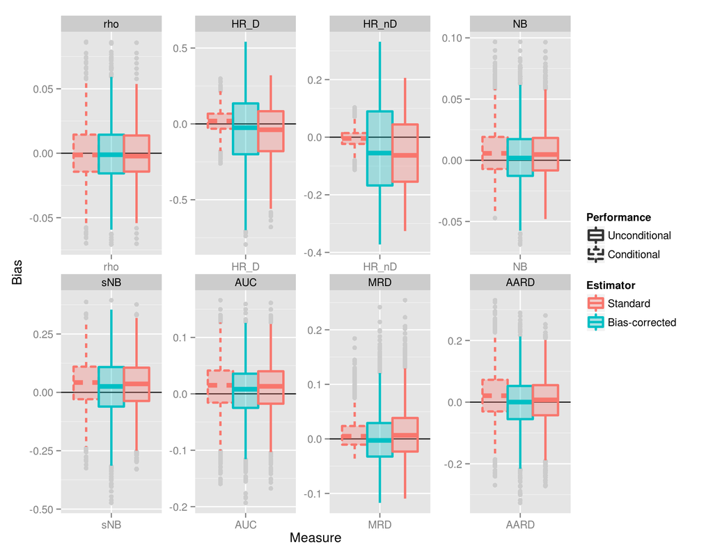